# Demo: Data Visualization

NIHES BST02

Eleni-Rosalina Andrinopoulou, Department of Biostatistics, Erasmus Medical Center

03 February 2021

## Load packages

If you are using the package for the first time, you will first have to install it.

```r
# install.packages("survival")
# install.packages("lattice")
# install.packages("ggplot2")
# install.packages("emojifont")
# install.packages("gtrendsR")
```

If you have already downloaded this package in the current version of R, you will only have to load the package.

```r
library(survival)
library(lattice)
library(ggplot2)
library(emojifont)
library(gtrendsR)
```

## Get the data

Load a data set from a package.  
You can use the double colon symbol (:), to return the pbc and pbcseq objects from the package survival. We store these data sets to new objects with the names pbc and pbcseq.

```r
pbc <- survival::pbc
pbcseq <- survival::pbcseq
```

## Basic plots

Basic plot with 1 continuous variable using the function `plot()`. For example, investigate the variable `bili` of the pbc data set.

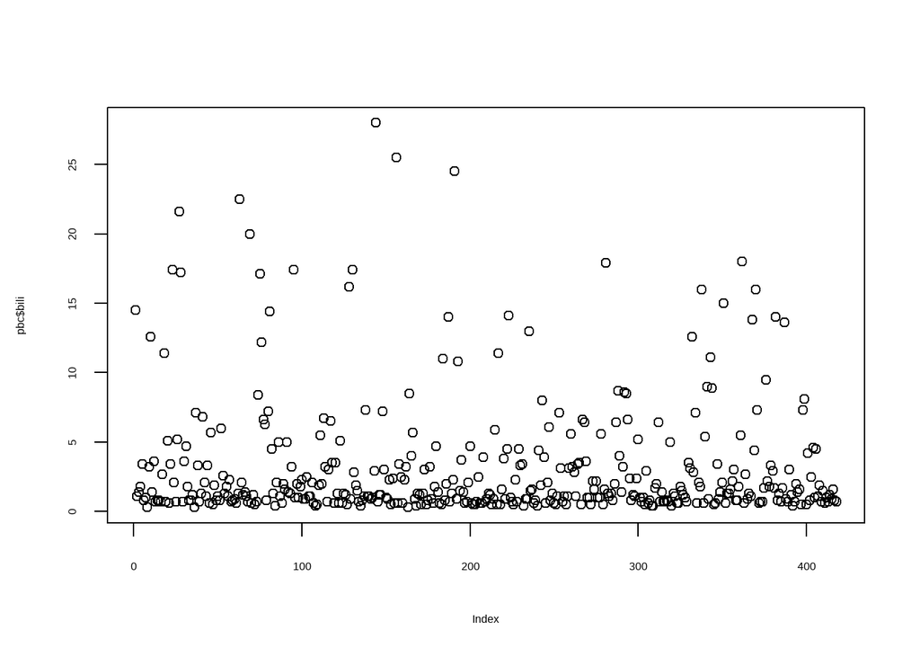

```r
plot(x = pbc$bili)
```

Basic plot with 2 continuous variables. For example, Check the correlation between `age` and `bili` of the pbc data set.

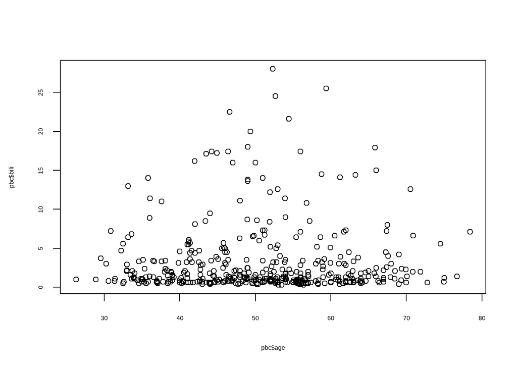

```r
plot(x = pbc$age, y = pbc$bili)
```

Basic plot with 2 continuous variables. Now, insert labels for the x and y-axis (use the argument xlab).

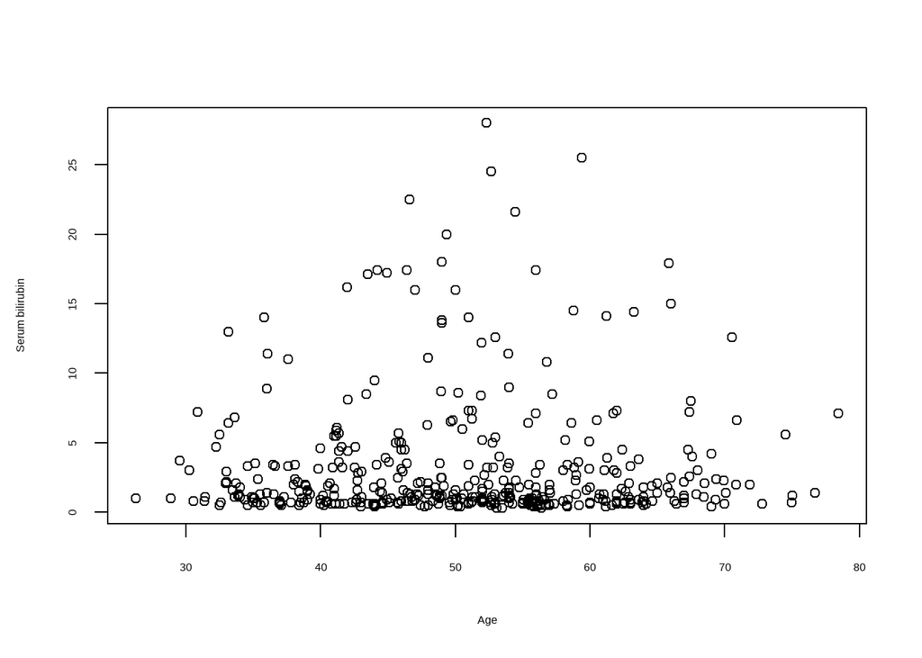

```r
plot(x = pbc$age, y = pbc$bili, ylab = "Serum bilirubin", xlab = "Age")
```

Basic plot with 2 continuous variables. Now, insert labels for the x and y-axis and change the size of the axis and labels (use the arguments cex.axis and cex.lab).

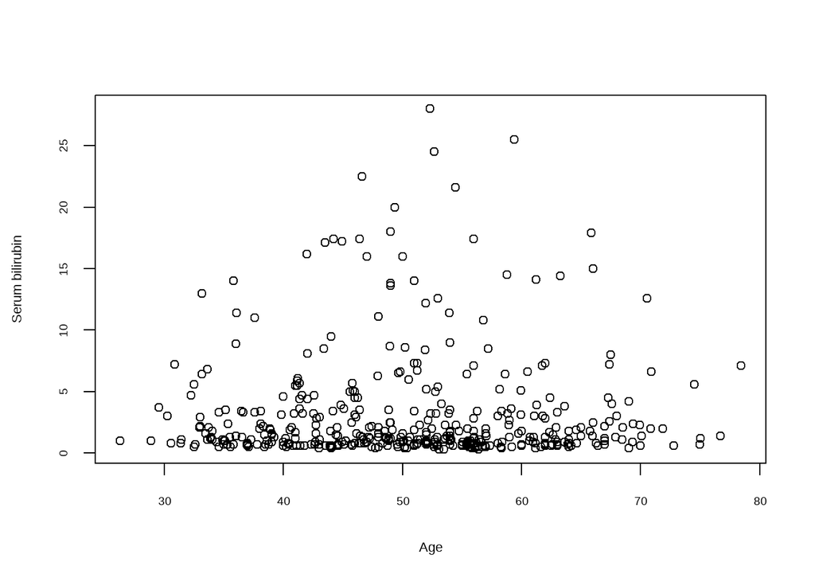

```r
plot(x = pbc$age, y = pbc$bili, ylab = "Serum bilirubin", xlab = "Age",
     cex.axis = 1.2, cex.lab = 1.4)
```

Basic plot with 2 continuous variables. Insert axis labels and change the size and type of points. Change also the size and the type of the points (use the arguments cex and pch). If you are not sure which arguments to use, check the help page.

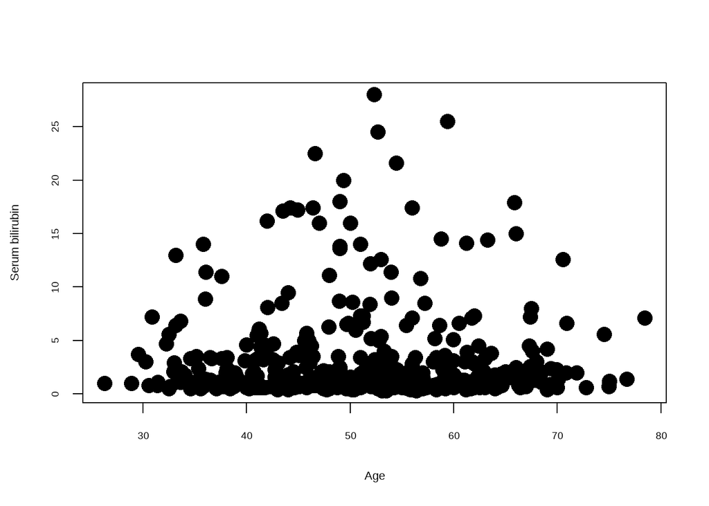

```r
plot(x = pbc$age, y = pbc$bili, ylab = "Serum bilirubin", xlab = "Age",
     cex.axis = 1.2, cex.lab = 1.4,
     cex = 2, pch = 16)
```

Basic plot with 2 continuous variables. Insert labels for the x and y-axis and change the size of the axis and labels. Change also the colour of the points.  
Note that we can set the colours in different ways:  
* using numbers that correspond to a colour  
* using the name of the colour  
* using the RGB colour specification (Red Green Blue) `?rgb`  
* using the HEX colour code

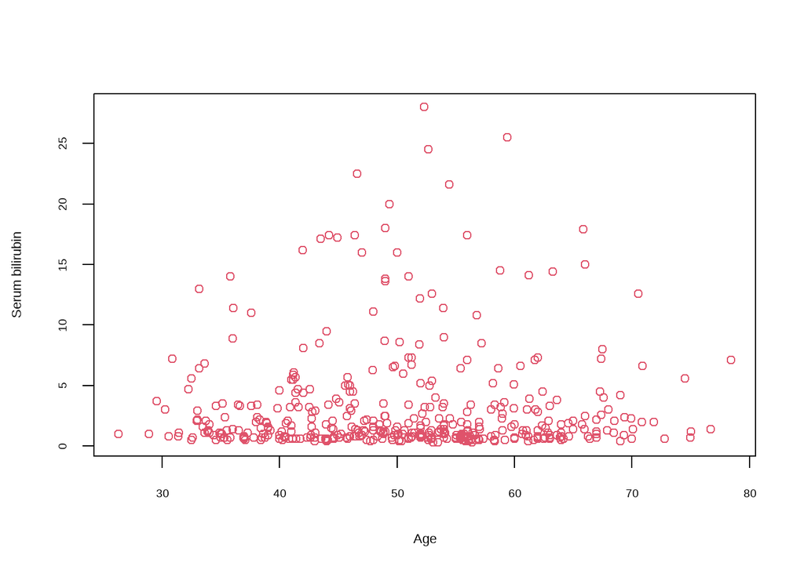

```r
plot(x = pbc$age, y = pbc$bili, ylab = "Serum bilirubin", xlab = "Age",
     cex.axis = 1.2, cex.lab = 1.4,
     col = 2)
```

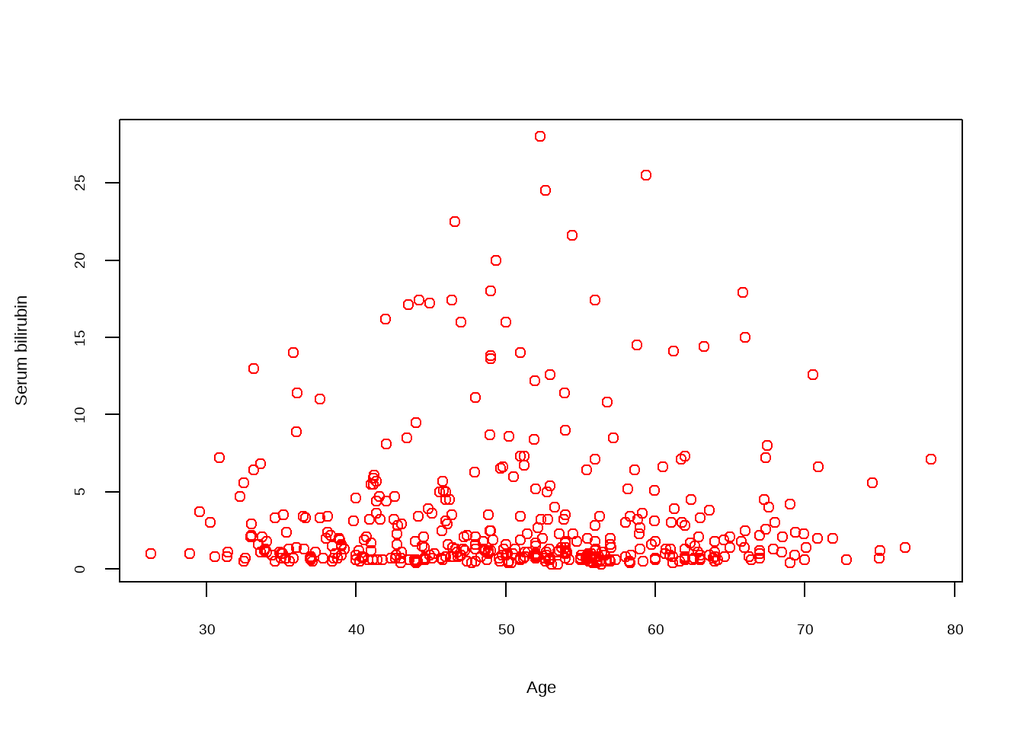

```r
plot(x = pbc$age, y = pbc$bili, ylab = "Serum bilirubin", xlab = "Age",
     cex.axis = 1.2, cex.lab = 1.4,
     col = "red")
```

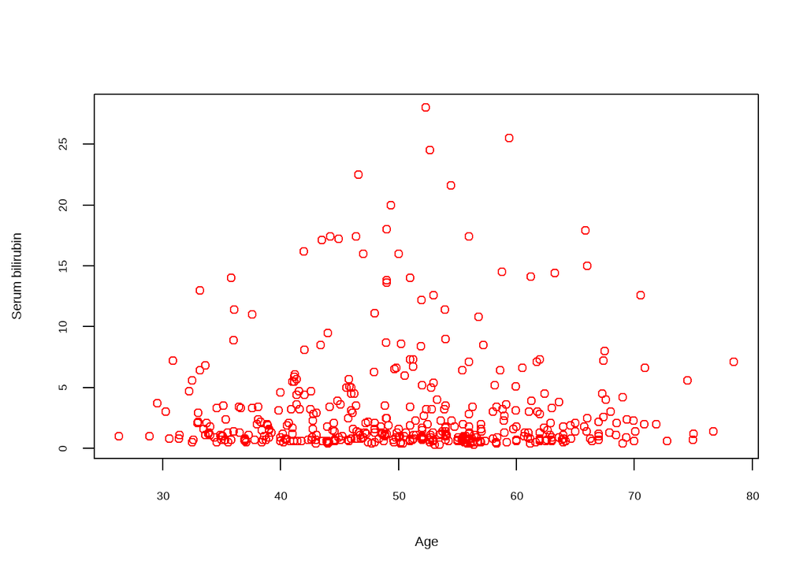

```r
plot(x = pbc$age, y = pbc$bili, ylab = "Serum bilirubin", xlab = "Age",
     cex.axis = 1.2, cex.lab = 1.4,
     col = rgb(1,0,0))
```

```r
plot(x = pbc$age, y = pbc$bili, ylab = "Serum bilirubin", xlab = "Age",
     cex.axis = 1.2, cex.lab = 1.4,
     col = "#FF0000")
```

[output not shown]

Basic plot with 3 variables (2 continuous and 1 categorical). X-axis represents `age`, y-axis represents `serum bilirubin` and colours represent `sex`.

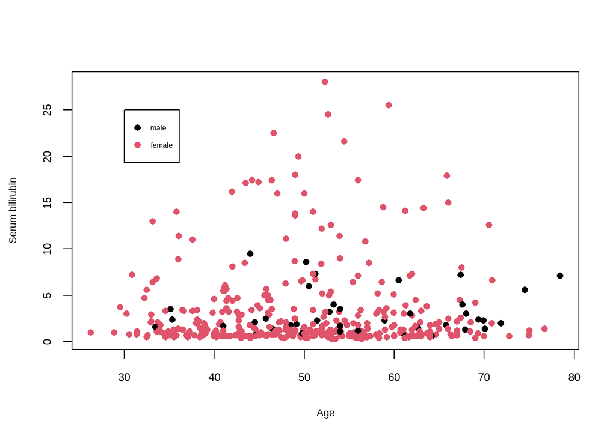

```r
plot(x = pbc$age, y = pbc$bili, ylab = "Serum bilirubin", xlab = "Age",
     cex.axis = 1.5, cex.lab = 1.4, col = pbc$sex, pch = 16)
legend(30, 25, legend = c("male", "female"), col = c(1,2), pch = 16)
```

Histogram for continuous variables. Check the distribution of `bili` and investigate the argument breaks and length.

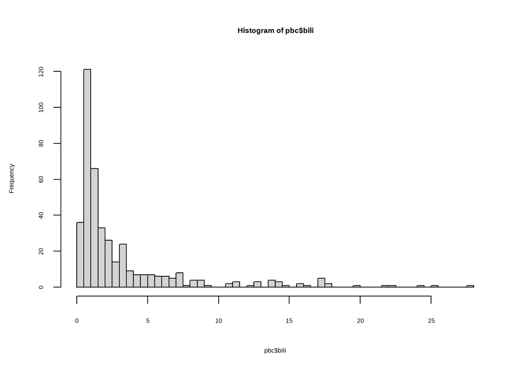

```r
hist(x = pbc$bili, breaks = 50)
```

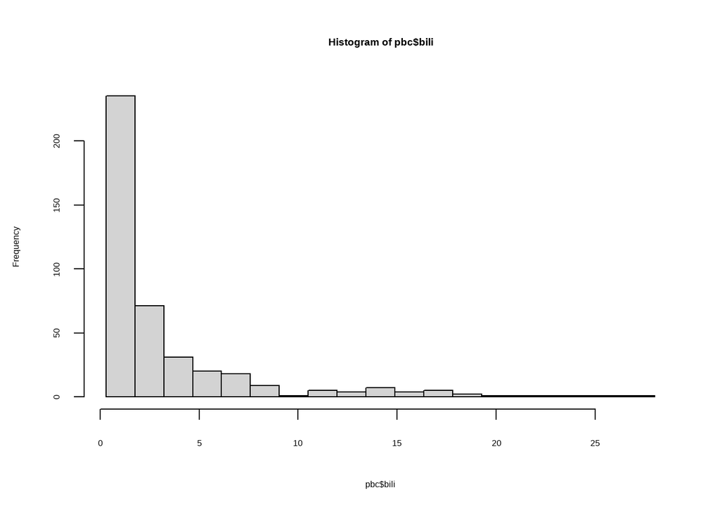

```r
hist(x = pbc$bili, breaks = seq(min(pbc$bili), max(pbc$bili), length = 20))
```

Multiple panels (using the `par()` function).

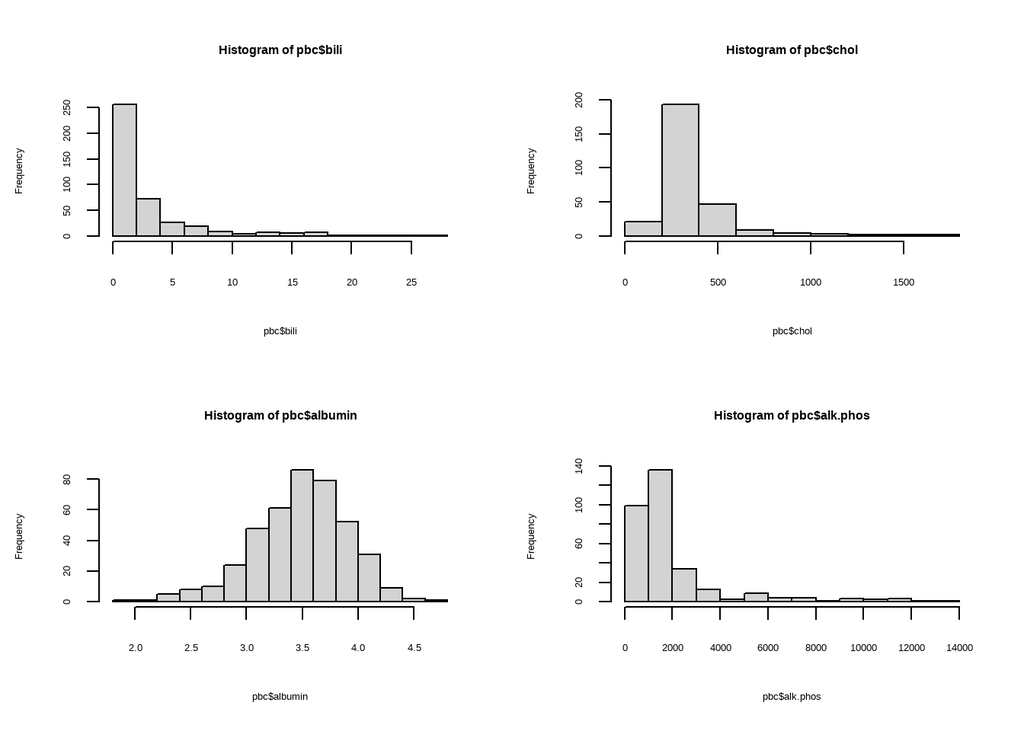

```r
par(mfrow=c(2,2))
hist(x = pbc$bili, freq = TRUE)
hist(x = pbc$chol, freq = TRUE)
hist(x = pbc$albumin, freq = TRUE)
hist(x = pbc$alk.phos, freq = TRUE)
```

Check what the argument freq does.  
Tip: Note that sometimes you will have to clear all plots in order to get 1 panel again (brush icon in `Plots` tab). Barchart for categorical variables using the function `plot()`. Check the frequency of `males` and `females`.

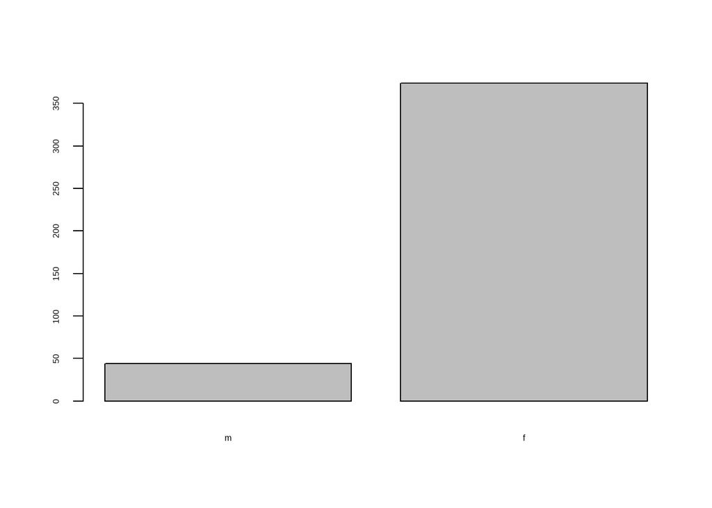

```r
plot(x = pbc$sex)
```

Piechart for categorical variables using the functions `pie()` and `table()`. Check the frequency of `males` and `females`.

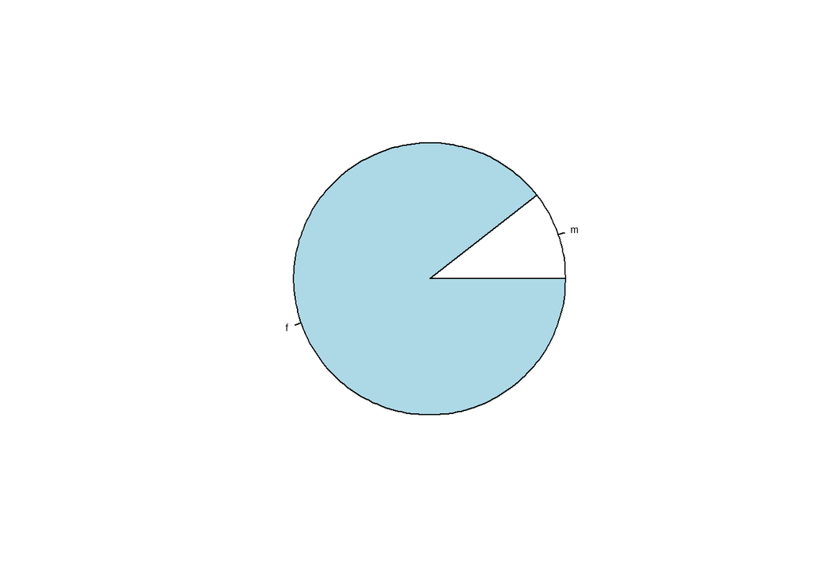

```r
pie(x = table(pbc$sex))
```

Boxplot for investigating the distribution of a continuous variable per group using the function `boxplot()`. Check the distribution of `age` per `sex` group.

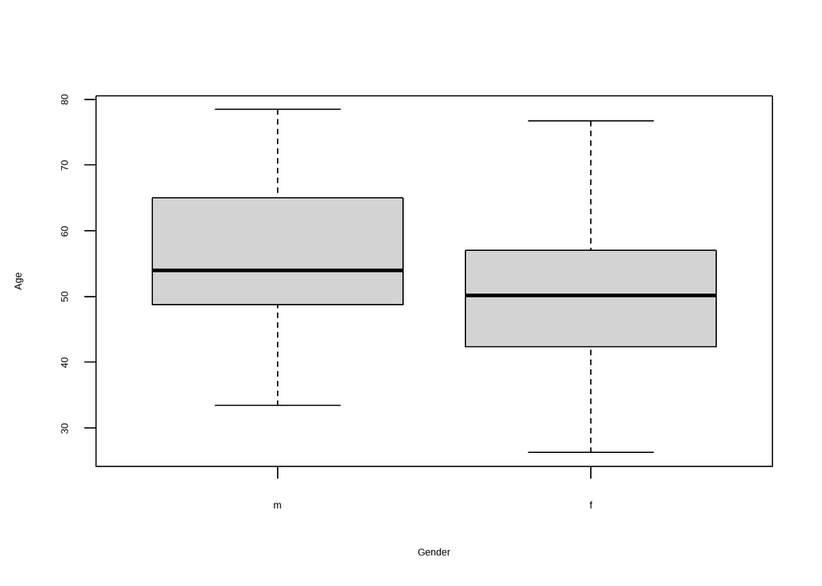

```r
boxplot(formula = pbc$age ~ pbc$sex, ylab = "Age", xlab = "Gender")
```

Multivariate plot of the variables `bili`, `chol` and `albumin`. We first need to create a matrix/data.frame.

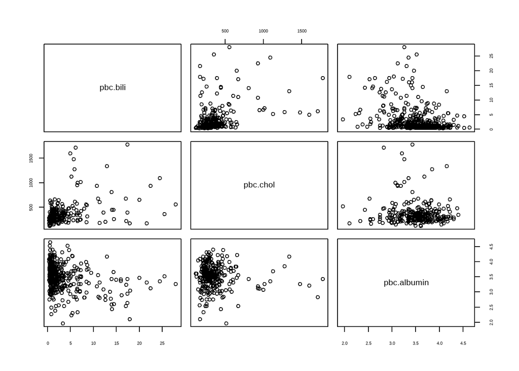

```r
pairs(x = data.frame(pbc$bili, pbc$chol, pbc$albumin))
```

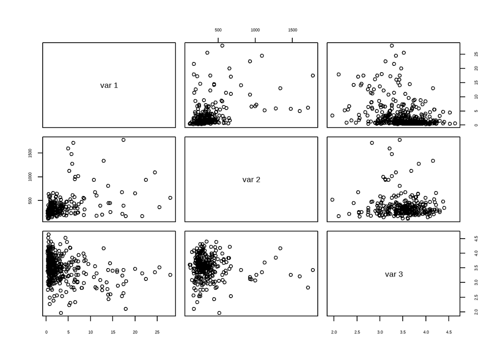

```r
pairs(x = cbind(pbc$bili, pbc$chol, pbc$albumin))
```

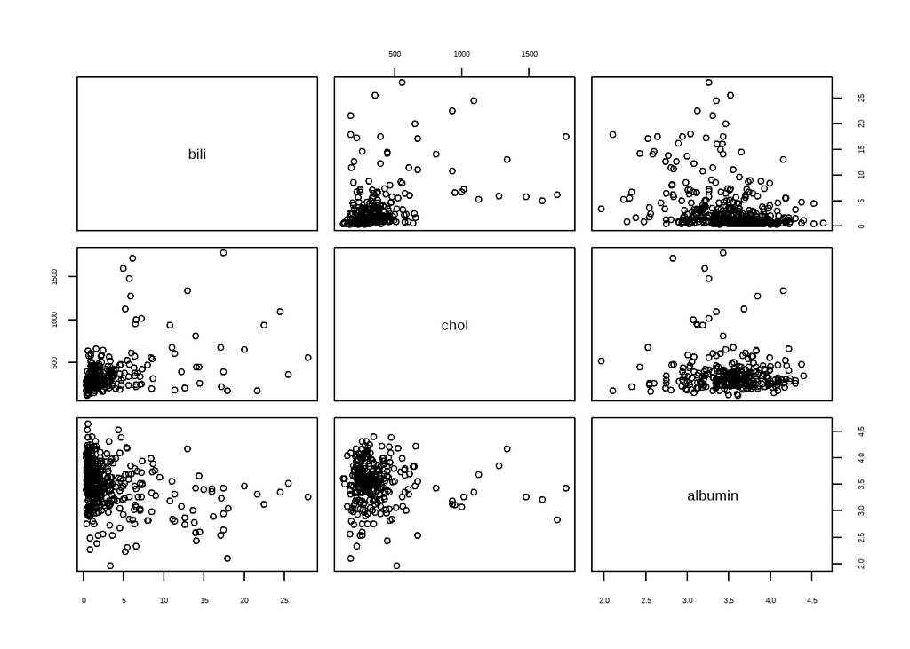

```r
pairs(formula = ~ bili + chol + albumin, data = pbc)
```

In the last case we set the data set to pbc. That means that we do not have to specify pbc every time we select a variable. The function knows that it has to look in the pbc data set for these names. Density plots of `bili` per `sex` group to investigate the distribution.  
Several ways exist to obtain this plot.

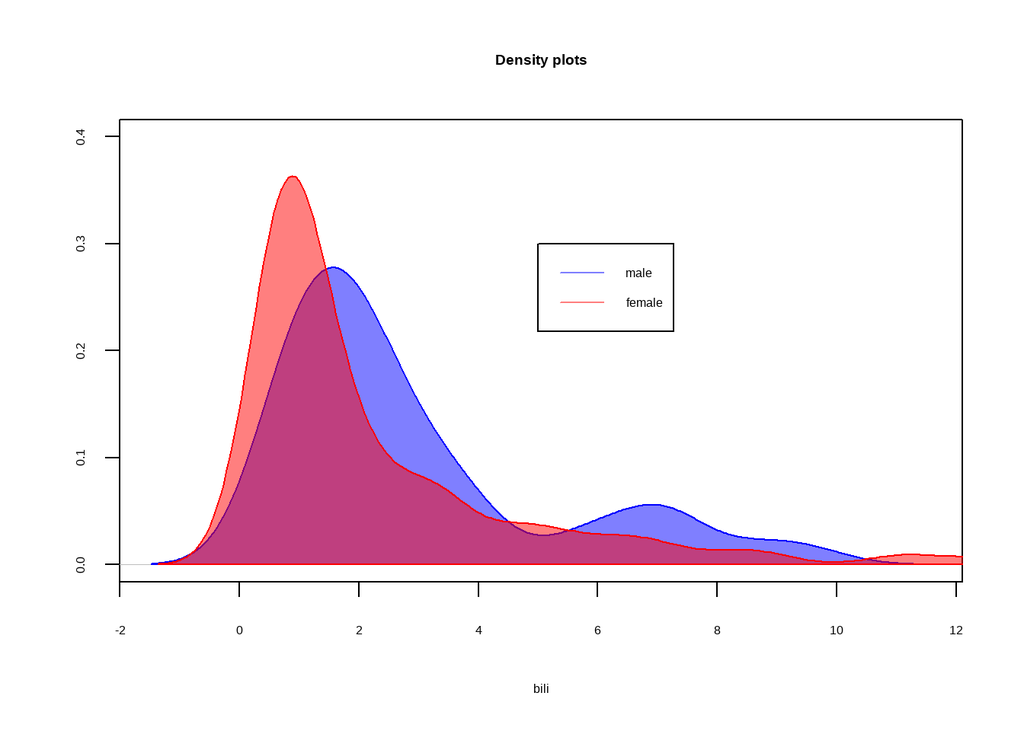

```r
# Here we start by assigning the `bili` values for `males` and `females` to a new object.
pbc_male_bili <- pbc$bili[pbc$sex == "m"]
pbc_female_bili <- pbc$bili[pbc$sex == "f"]
# We first plot the `bili` values for `males`.
plot(density(pbc_male_bili), col = rgb(0,0,1,0.5), ylim = c(0,0.40),
     main = "Density plots", xlab = "bili", ylab = "")
# Then we fill in the area under the curve using the function `polygon()`.
polygon(density(pbc_male_bili), col = rgb(0,0,1,0.5), border = "blue")
# Then we add the `bili` values for `females`. Since a plot has been already specified we can use the function `lines()` to add a line.
lines(density(pbc_female_bili), col = rgb(1,0,0,0.5))
# Then we fill in the area under the curve using the function `polygon()`.
polygon(density(pbc_female_bili), col = rgb(1,0,0,0.5), border = "red")
# Finally, we add a legend using the `legend()` function.
legend(5,0.3, legend = c("male", "female"),
       col = c(rgb(0,0,1,0.5), rgb(1,0,0,0.5)), lty = 1)
```

## Lattice family

Correlation between `bili` and `age`. Investigate the arguments type and lwd.

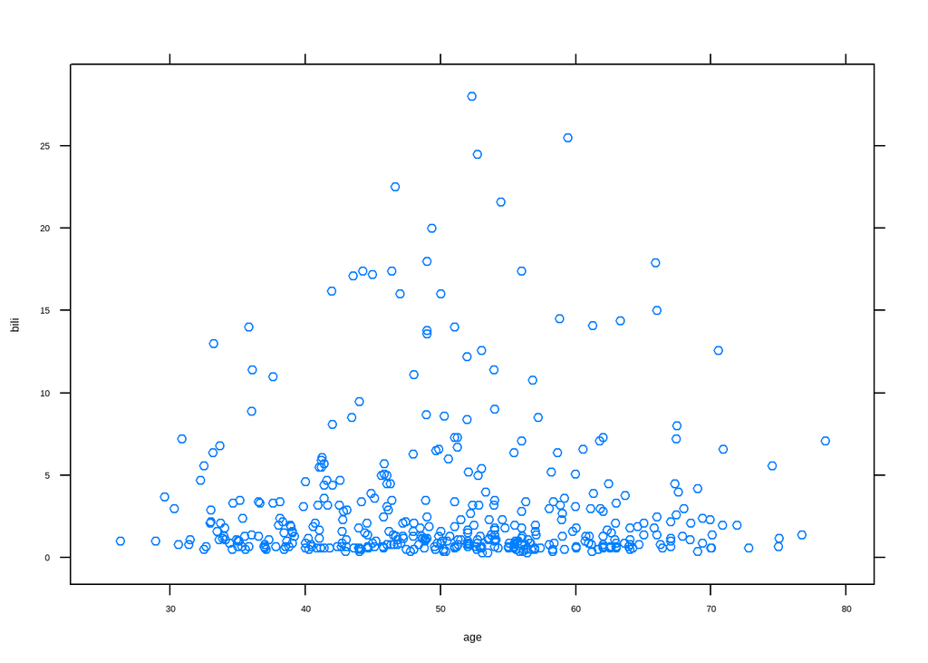

```r
xyplot(x = bili ~ age, data = pbc, type = "p", lwd = 2)
```

Smooth evolution of `bili` with `age`. To change the type of plot use the argument type.

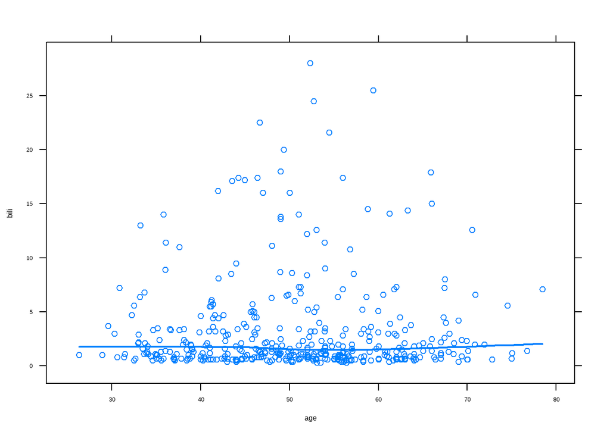

```r
xyplot(x = bili ~ age, data = pbc, type = c("p", "smooth"), lwd = 2)
```

Smooth evolution of `bili` with `age` per `sex`. Assume different colours for each `sex` category using the group argument.

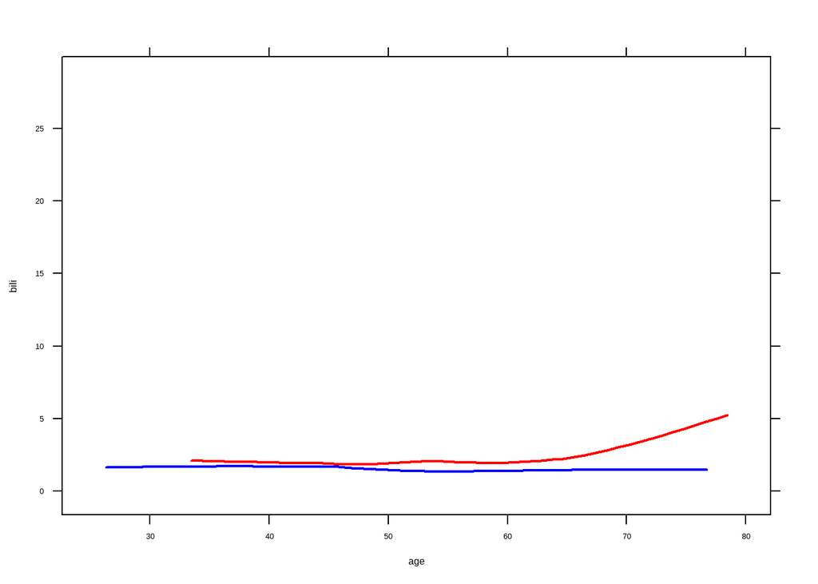

```r
xyplot(x = bili ~ age, group = sex, data = pbc, type = "smooth",
       lwd = 2, col = c("red", "blue"))
```

Smooth evolution with points of `bili` with `age` per `sex`. Assume different colours for each `sex` category.

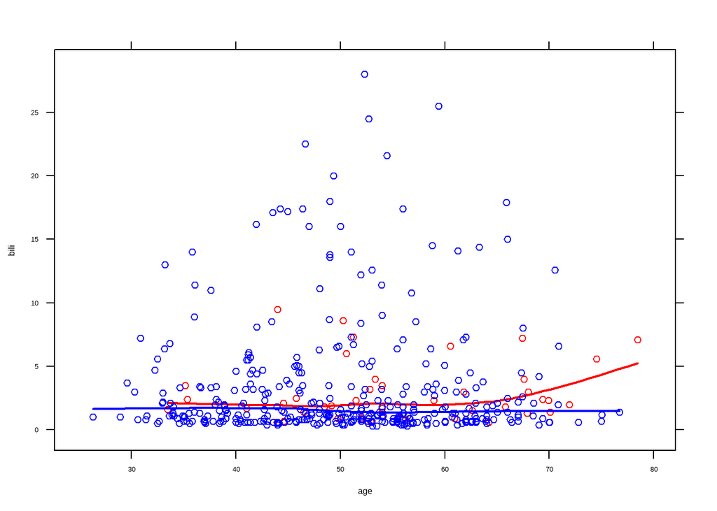

```r
xyplot(x = bili ~ age, group = sex, data = pbc, type = c("p", "smooth"),
       lwd = 2, col = c("red", "blue"))
```

Smooth evolution with points of `bili` with `age` per `sex` (as separate panel).

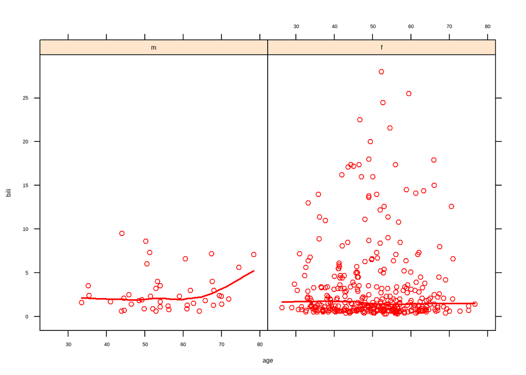

```r
xyplot(x = bili ~ age | sex, data = pbc, type = c("p", "smooth"),
       lwd = 2, col = c("red"))
```

Smooth evolution with points of `bili` with `age` per `status` (as separate panel).

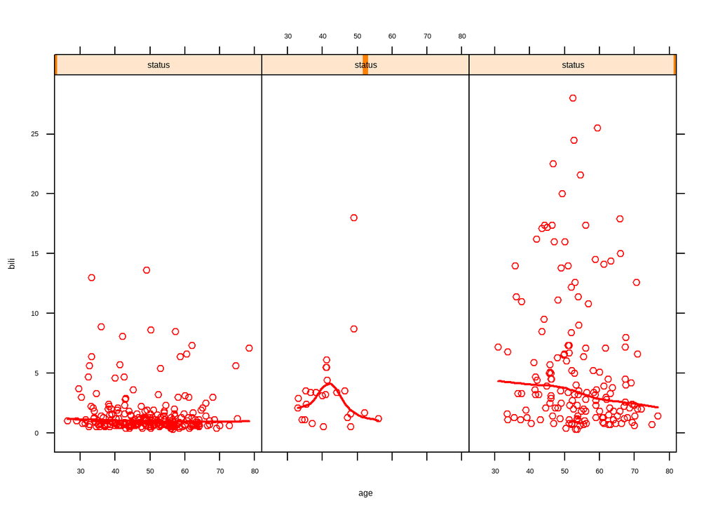

```r
xyplot(x = bili ~ age | status, data = pbc, type = c("p", "smooth"),
       lwd = 2, col = c("red"))
```

Smooth evolution with points of `bili` with `age` per `status` (as separate panel - change layout).

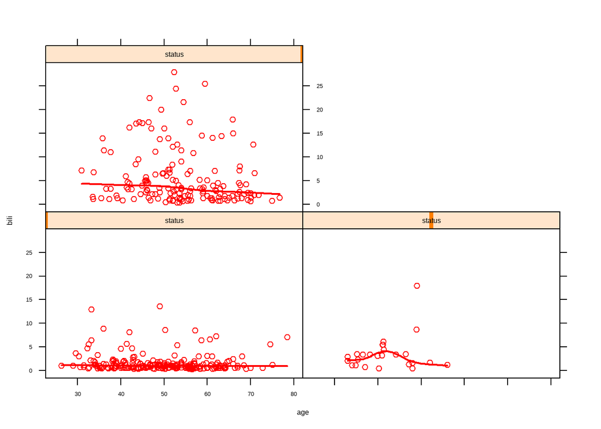

```r
xyplot(x = bili ~ age | status, data = pbc, type = c("p", "smooth"),
       lwd = 2, col = c("red"), layout = c(2,2))
```

Smooth evolution with points of `bili` with `age` per `status` (as separate panel - change layout).  
Transform `status` into a factor with labels and run the plot again.

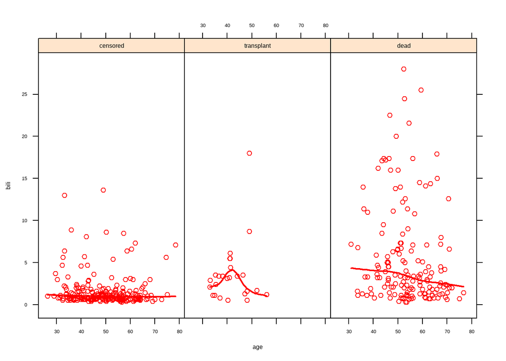

```r
pbc$status <- factor(x = pbc$status, levels = c(0, 1, 2),
                     labels = c("censored", "transplant", "dead"))
xyplot(x = bili ~ age | status, data = pbc, type = c("p", "smooth"),
       lwd = 2, col = c("red"), layout = c(3,1))
```

Individual patient plot.

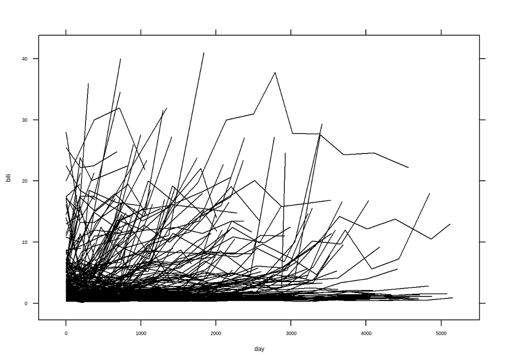

```r
xyplot(x = bili ~ day, group = id, data = pbcseq, type = "l", col = "black")
```

Individual patient plot per `status`.

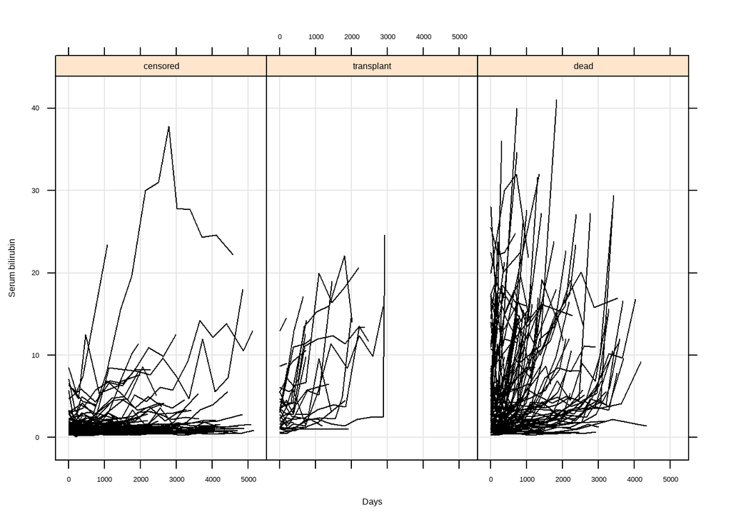

```r
pbcseq$status <- factor(x = pbcseq$status, levels = c(0, 1, 2),
                        labels = c("censored", "transplant", "dead"))
xyplot(x = bili ~ day | status, group = id, data = pbcseq, type = "l",
       col = "black", layout = c(3,1),
       grid = TRUE, xlab = "Days", ylab = "Serum bilirubin")
```

Barchart for categorical variables using the function `barchart()`. Checking the frequency of `males` and `females`.

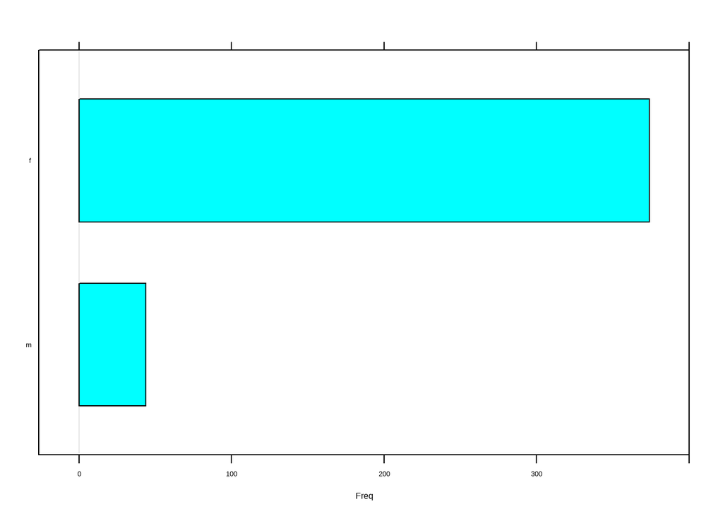

```r
barchart(x = pbc$sex)
```

Boxplot of `serum bilirubin` per `sex` group using the function `bwplot()`.

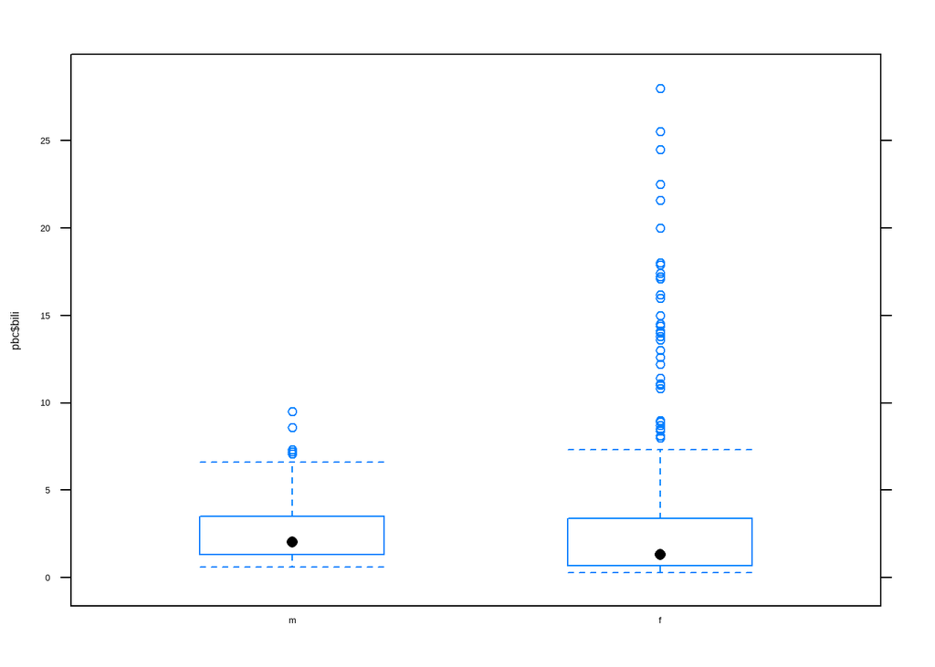

```r
bwplot(x = pbc$bili ~ pbc$sex)
```